# Data Wrangling

2024-02-11

## Data Wrangling

A task that consumes most of the analyst’s time is getting the data in the right format and content. This task could include removing missing values, recoding variables, identifying noise points, choosing the right data type, etc. Once data has been coded properly, the analyst’s task could involve selecting a part of the data (filtering), summarizing, and sorting by different measures. This may also include combining different datasets, creating new variables, and other data manipulation.

R has many ways to accomplish the above. We will use [dplyr](https://dplyr.tidyverse.org/) package developed by Hadley Wickham for these tasks.

#### Load Packages

```r
library(dplyr)
```

We will use the *mtcars* built in dataset to illustrate all data manipulation exercises in this section

### Subsetting or Filtering

Before we use dplyr, let us look at some basic subsetting examples

```r
x <- c(4, 3, 8, 2, 4) # create a vector

# Now, let's subset. Note the use of  [ ]
x[3] # This gives the third element of the vector
```

```
## [1] 8
```

```r
x[1:4] # Elements 1 through 4
```

```
## [1] 4 3 8 2
```

```r
x[-3] # All elements except 3
```

```
## [1] 4 3 2 4
```

```r
x[c(2, 5)] # The second and fifth elements
```

```
## [1] 3 4
```

```r
# Now, let's try conditional subsetting
x[x>3] # All values > 3
```

```
## [1] 4 8 4
```

```r
x[x> 3 & x==8] # All values > 3 and = 8. Note the use of "=="
```

```
## [1] 8
```

```r
x[x< 3 | x==4] # All values > 3 OR = 8. Note the use of "=="
```

```
## [1] 4 2 4
```

```r
# We can apply this to dataframes also

summary(mtcars)
```

```
##       mpg             cyl             disp             hp
##  Min.   :10.40   Min.   :4.000   Min.   : 71.1   Min.   : 52.0
##  1st Qu.:15.43   1st Qu.:4.000   1st Qu.:120.8   1st Qu.: 96.5
##  Median :19.20   Median :6.000   Median :196.3   Median :123.0
##  Mean   :20.09   Mean   :6.188   Mean   :230.7   Mean   :146.7
##  3rd Qu.:22.80   3rd Qu.:8.000   3rd Qu.:326.0   3rd Qu.:180.0
##  Max.   :33.90   Max.   :8.000   Max.   :472.0   Max.   :335.0
##       drat             wt             qsec             vs
##  Min.   :2.760   Min.   :1.513   Min.   :14.50   Min.   :0.0000
##  1st Qu.:3.080   1st Qu.:2.581   1st Qu.:16.89   1st Qu.:0.0000
##  Median :3.695   Median :3.325   Median :17.71   Median :0.0000
##  Mean   :3.597   Mean   :3.217   Mean   :17.85   Mean   :0.4375
##  3rd Qu.:3.920   3rd Qu.:3.610   3rd Qu.:18.90   3rd Qu.:1.0000
##  Max.   :4.930   Max.   :5.424   Max.   :22.90   Max.   :1.0000
##        am              gear            carb
##  Min.   :0.0000   Min.   :3.000   Min.   :1.000
##  1st Qu.:0.0000   1st Qu.:3.000   1st Qu.:2.000
##  Median :0.0000   Median :4.000   Median :2.000
##  Mean   :0.4062   Mean   :3.688   Mean   :2.812
##  3rd Qu.:1.0000   3rd Qu.:4.000   3rd Qu.:4.000
##  Max.   :1.0000   Max.   :5.000   Max.   :8.000
```

```r
head(mtcars)
```

```
##                    mpg cyl disp  hp drat    wt  qsec vs am gear carb
## Mazda RX4         21.0   6  160 110 3.90 2.620 16.46  0  1    4    4
## Mazda RX4 Wag     21.0   6  160 110 3.90 2.875 17.02  0  1    4    4
## Datsun 710        22.8   4  108  93 3.85 2.320 18.61  1  1    4    1
## Hornet 4 Drive    21.4   6  258 110 3.08 3.215 19.44  1  0    3    1
## Hornet Sportabout 18.7   8  360 175 3.15 3.440 17.02  0  0    3    2
## Valiant           18.1   6  225 105 2.76 3.460 20.22  1  0    3    1
```

```r
mtcars[4:6,2] # give rows 4 through 6, for column (variable) 2
```

```
## [1] 6 8 6
```

```r
mtcars[mtcars$mpg>25,] # Choose all variables for cars with mpg > 25
```

```
##                 mpg cyl  disp  hp drat    wt  qsec vs am gear carb
## Fiat 128       32.4   4  78.7  66 4.08 2.200 19.47  1  1    4    1
## Honda Civic    30.4   4  75.7  52 4.93 1.615 18.52  1  1    4    2
## Toyota Corolla 33.9   4  71.1  65 4.22 1.835 19.90  1  1    4    1
## Fiat X1-9      27.3   4  79.0  66 4.08 1.935 18.90  1  1    4    1
## Porsche 914-2  26.0   4 120.3  91 4.43 2.140 16.70  0  1    5    2
## Lotus Europa   30.4   4  95.1 113 3.77 1.513 16.90  1  1    5    2
```

```r
mtcars[mtcars$mpg>20 & mtcars$cyl>4,1:2]
```

```
##                 mpg cyl
## Mazda RX4      21.0   6
## Mazda RX4 Wag  21.0   6
## Hornet 4 Drive 21.4   6
```

### Overview - dplyr

The following overview is directly from the [website](https://dplyr.tidyverse.org/)

dplyr is a grammar of data manipulation, providing a consistent set of verbs that help you solve the most common data manipulation challenges:

- mutate() adds new variables that are functions of existing variables
- select() picks variables based on their names.
- filter() picks cases based on their values.
- summarise() reduces multiple values down to a single summary.
- arrange() changes the ordering of the rows.

These all combine naturally with *group_by()* which allows you to perform any operation “by group”. You can learn more about them in *vignette(“dplyr”)*. As well as these single-table verbs, dplyr also provides a variety of two-table verbs, which you can learn about in *vignette(“two-table”)*.

If you are new to dplyr, the best place to start is the data transformation chapter in [R for Data Science](https://r4ds.hadley.nz/data-transform).

#### Subsetting

```r
library(dplyr)
filter(mtcars, mpg>25) # find all data for cars with mpg > 25
```

```
##                 mpg cyl  disp  hp drat    wt  qsec vs am gear carb
## Fiat 128       32.4   4  78.7  66 4.08 2.200 19.47  1  1    4    1
## Honda Civic    30.4   4  75.7  52 4.93 1.615 18.52  1  1    4    2
## Toyota Corolla 33.9   4  71.1  65 4.22 1.835 19.90  1  1    4    1
## Fiat X1-9      27.3   4  79.0  66 4.08 1.935 18.90  1  1    4    1
## Porsche 914-2  26.0   4 120.3  91 4.43 2.140 16.70  0  1    5    2
## Lotus Europa   30.4   4  95.1 113 3.77 1.513 16.90  1  1    5    2
```

```r
select(mtcars,mpg) # this selects only the mpg variable
```

```
##                      mpg
## Mazda RX4           21.0
## Mazda RX4 Wag       21.0
## Datsun 710          22.8
## Hornet 4 Drive      21.4
## Hornet Sportabout   18.7
## Valiant             18.1
## Duster 360          14.3
## Merc 240D           24.4
## Merc 230            22.8
## Merc 280            19.2
## Merc 280C           17.8
## Merc 450SE          16.4
## Merc 450SL          17.3
## Merc 450SLC         15.2
## Cadillac Fleetwood  10.4
## Lincoln Continental 10.4
## Chrysler Imperial   14.7
## Fiat 128            32.4
## Honda Civic         30.4
## Toyota Corolla      33.9
## Toyota Corona       21.5
## Dodge Challenger    15.5
## AMC Javelin         15.2
## Camaro Z28          13.3
## Pontiac Firebird    19.2
## Fiat X1-9           27.3
## Porsche 914-2       26.0
## Lotus Europa        30.4
## Ford Pantera L      15.8
## Ferrari Dino        19.7
## Maserati Bora       15.0
## Volvo 142E          21.4
```

```r
select(mtcars,c(mpg,cyl)) # this selects mpg and cyl
```

```
##                      mpg cyl
## Mazda RX4           21.0   6
## Mazda RX4 Wag       21.0   6
## Datsun 710          22.8   4
## Hornet 4 Drive      21.4   6
## Hornet Sportabout   18.7   8
## Valiant             18.1   6
## Duster 360          14.3   8
## Merc 240D           24.4   4
## Merc 230            22.8   4
## Merc 280            19.2   6
## Merc 280C           17.8   6
## Merc 450SE          16.4   8
## Merc 450SL          17.3   8
## Merc 450SLC         15.2   8
## Cadillac Fleetwood  10.4   8
## Lincoln Continental 10.4   8
## Chrysler Imperial   14.7   8
## Fiat 128            32.4   4
## Honda Civic         30.4   4
## Toyota Corolla      33.9   4
## Toyota Corona       21.5   4
## Dodge Challenger    15.5   8
## AMC Javelin         15.2   8
## Camaro Z28          13.3   8
## Pontiac Firebird    19.2   8
## Fiat X1-9           27.3   4
## Porsche 914-2       26.0   4
## Lotus Europa        30.4   4
## Ford Pantera L      15.8   8
## Ferrari Dino        19.7   6
## Maserati Bora       15.0   8
## Volvo 142E          21.4   4
```

```r
select(mtcars,1:3) # selects first three variable
```

```
##                      mpg cyl  disp
## Mazda RX4           21.0   6 160.0
## Mazda RX4 Wag       21.0   6 160.0
## Datsun 710          22.8   4 108.0
## Hornet 4 Drive      21.4   6 258.0
## Hornet Sportabout   18.7   8 360.0
## Valiant             18.1   6 225.0
## Duster 360          14.3   8 360.0
## Merc 240D           24.4   4 146.7
## Merc 230            22.8   4 140.8
## Merc 280            19.2   6 167.6
## Merc 280C           17.8   6 167.6
## Merc 450SE          16.4   8 275.8
## Merc 450SL          17.3   8 275.8
## Merc 450SLC         15.2   8 275.8
## Cadillac Fleetwood  10.4   8 472.0
## Lincoln Continental 10.4   8 460.0
## Chrysler Imperial   14.7   8 440.0
## Fiat 128            32.4   4  78.7
## Honda Civic         30.4   4  75.7
## Toyota Corolla      33.9   4  71.1
## Toyota Corona       21.5   4 120.1
## Dodge Challenger    15.5   8 318.0
## AMC Javelin         15.2   8 304.0
## Camaro Z28          13.3   8 350.0
## Pontiac Firebird    19.2   8 400.0
## Fiat X1-9           27.3   4  79.0
## Porsche 914-2       26.0   4 120.3
## Lotus Europa        30.4   4  95.1
## Ford Pantera L      15.8   8 351.0
## Ferrari Dino        19.7   6 145.0
## Maserati Bora       15.0   8 301.0
## Volvo 142E          21.4   4 121.0
```

```r
select(mtcars,starts_with("m")) # all variables that start with m
```

```
##                      mpg
## Mazda RX4           21.0
## Mazda RX4 Wag       21.0
## Datsun 710          22.8
## Hornet 4 Drive      21.4
## Hornet Sportabout   18.7
## Valiant             18.1
## Duster 360          14.3
## Merc 240D           24.4
## Merc 230            22.8
## Merc 280            19.2
## Merc 280C           17.8
## Merc 450SE          16.4
## Merc 450SL          17.3
## Merc 450SLC         15.2
## Cadillac Fleetwood  10.4
## Lincoln Continental 10.4
## Chrysler Imperial   14.7
## Fiat 128            32.4
## Honda Civic         30.4
## Toyota Corolla      33.9
## Toyota Corona       21.5
## Dodge Challenger    15.5
## AMC Javelin         15.2
## Camaro Z28          13.3
## Pontiac Firebird    19.2
## Fiat X1-9           27.3
## Porsche 914-2       26.0
## Lotus Europa        30.4
## Ford Pantera L      15.8
## Ferrari Dino        19.7
## Maserati Bora       15.0
## Volvo 142E          21.4
```

Now, let us look at some useful filterning and subsetting operations

```r
# remove duplicates
distinct(mtcars)
```

```
##                      mpg cyl  disp  hp drat    wt  qsec vs am gear carb
## Mazda RX4           21.0   6 160.0 110 3.90 2.620 16.46  0  1    4    4
## Mazda RX4 Wag       21.0   6 160.0 110 3.90 2.875 17.02  0  1    4    4
## Datsun 710          22.8   4 108.0  93 3.85 2.320 18.61  1  1    4    1
## Hornet 4 Drive      21.4   6 258.0 110 3.08 3.215 19.44  1  0    3    1
## Hornet Sportabout   18.7   8 360.0 175 3.15 3.440 17.02  0  0    3    2
## Valiant             18.1   6 225.0 105 2.76 3.460 20.22  1  0    3    1
## Duster 360          14.3   8 360.0 245 3.21 3.570 15.84  0  0    3    4
## Merc 240D           24.4   4 146.7  62 3.69 3.190 20.00  1  0    4    2
## Merc 230            22.8   4 140.8  95 3.92 3.150 22.90  1  0    4    2
## Merc 280            19.2   6 167.6 123 3.92 3.440 18.30  1  0    4    4
## Merc 280C           17.8   6 167.6 123 3.92 3.440 18.90  1  0    4    4
## Merc 450SE          16.4   8 275.8 180 3.07 4.070 17.40  0  0    3    3
## Merc 450SL          17.3   8 275.8 180 3.07 3.730 17.60  0  0    3    3
## Merc 450SLC         15.2   8 275.8 180 3.07 3.780 18.00  0  0    3    3
## Cadillac Fleetwood  10.4   8 472.0 205 2.93 5.250 17.98  0  0    3    4
## Lincoln Continental 10.4   8 460.0 215 3.00 5.424 17.82  0  0    3    4
## Chrysler Imperial   14.7   8 440.0 230 3.23 5.345 17.42  0  0    3    4
## Fiat 128            32.4   4  78.7  66 4.08 2.200 19.47  1  1    4    1
## Honda Civic         30.4   4  75.7  52 4.93 1.615 18.52  1  1    4    2
## Toyota Corolla      33.9   4  71.1  65 4.22 1.835 19.90  1  1    4    1
## Toyota Corona       21.5   4 120.1  97 3.70 2.465 20.01  1  0    3    1
## Dodge Challenger    15.5   8 318.0 150 2.76 3.520 16.87  0  0    3    2
## AMC Javelin         15.2   8 304.0 150 3.15 3.435 17.30  0  0    3    2
## Camaro Z28          13.3   8 350.0 245 3.73 3.840 15.41  0  0    3    4
## Pontiac Firebird    19.2   8 400.0 175 3.08 3.845 17.05  0  0    3    2
## Fiat X1-9           27.3   4  79.0  66 4.08 1.935 18.90  1  1    4    1
## Porsche 914-2       26.0   4 120.3  91 4.43 2.140 16.70  0  1    5    2
## Lotus Europa        30.4   4  95.1 113 3.77 1.513 16.90  1  1    5    2
## Ford Pantera L      15.8   8 351.0 264 4.22 3.170 14.50  0  1    5    4
## Ferrari Dino        19.7   6 145.0 175 3.62 2.770 15.50  0  1    5    6
## Maserati Bora       15.0   8 301.0 335 3.54 3.570 14.60  0  1    5    8
## Volvo 142E          21.4   4 121.0 109 4.11 2.780 18.60  1  1    4    2
```

```r
sample_frac(mtcars, 0.5, replace = TRUE) # Sample with replacement
```

```
##                     mpg cyl  disp  hp drat    wt  qsec vs am gear carb
## Volvo 142E         21.4   4 121.0 109 4.11 2.780 18.60  1  1    4    2
## Mazda RX4...2      21.0   6 160.0 110 3.90 2.620 16.46  0  1    4    4
## AMC Javelin        15.2   8 304.0 150 3.15 3.435 17.30  0  0    3    2
## Merc 450SLC        15.2   8 275.8 180 3.07 3.780 18.00  0  0    3    3
## Cadillac Fleetwood 10.4   8 472.0 205 2.93 5.250 17.98  0  0    3    4
## Merc 280           19.2   6 167.6 123 3.92 3.440 18.30  1  0    4    4
## Merc 450SE         16.4   8 275.8 180 3.07 4.070 17.40  0  0    3    3
## Ford Pantera L     15.8   8 351.0 264 4.22 3.170 14.50  0  1    5    4
## Dodge Challenger   15.5   8 318.0 150 2.76 3.520 16.87  0  0    3    2
## Fiat 128           32.4   4  78.7  66 4.08 2.200 19.47  1  1    4    1
## Mazda RX4...11     21.0   6 160.0 110 3.90 2.620 16.46  0  1    4    4
## Honda Civic        30.4   4  75.7  52 4.93 1.615 18.52  1  1    4    2
## Merc 450SL         17.3   8 275.8 180 3.07 3.730 17.60  0  0    3    3
## Merc 240D...14     24.4   4 146.7  62 3.69 3.190 20.00  1  0    4    2
## Merc 240D...15     24.4   4 146.7  62 3.69 3.190 20.00  1  0    4    2
## Lotus Europa       30.4   4  95.1 113 3.77 1.513 16.90  1  1    5    2
```

```r
set.seed(4321)
sample_n(mtcars, 10, replace = TRUE) # sample 10 rows
```

```
##                     mpg cyl  disp  hp drat    wt  qsec vs am gear carb
## Toyota Corona...1  21.5   4 120.1  97 3.70 2.465 20.01  1  0    3    1
## Ferrari Dino       19.7   6 145.0 175 3.62 2.770 15.50  0  1    5    6
## Porsche 914-2      26.0   4 120.3  91 4.43 2.140 16.70  0  1    5    2
## Fiat X1-9          27.3   4  79.0  66 4.08 1.935 18.90  1  1    4    1
## Toyota Corona...5  21.5   4 120.1  97 3.70 2.465 20.01  1  0    3    1
## Ford Pantera L     15.8   8 351.0 264 4.22 3.170 14.50  0  1    5    4
## Merc 280           19.2   6 167.6 123 3.92 3.440 18.30  1  0    4    4
## Volvo 142E         21.4   4 121.0 109 4.11 2.780 18.60  1  1    4    2
## Merc 450SLC        15.2   8 275.8 180 3.07 3.780 18.00  0  0    3    3
## Cadillac Fleetwood 10.4   8 472.0 205 2.93 5.250 17.98  0  0    3    4
```

```r
slice(mtcars, 10:15) #Select rows by position.
```

```
##                     mpg cyl  disp  hp drat   wt  qsec vs am gear carb
## Merc 280           19.2   6 167.6 123 3.92 3.44 18.30  1  0    4    4
## Merc 280C          17.8   6 167.6 123 3.92 3.44 18.90  1  0    4    4
## Merc 450SE         16.4   8 275.8 180 3.07 4.07 17.40  0  0    3    3
## Merc 450SL         17.3   8 275.8 180 3.07 3.73 17.60  0  0    3    3
## Merc 450SLC        15.2   8 275.8 180 3.07 3.78 18.00  0  0    3    3
## Cadillac Fleetwood 10.4   8 472.0 205 2.93 5.25 17.98  0  0    3    4
```

```r
slice_max(mtcars,mpg, n=10,by=cyl)
```

```
##                    mpg cyl  disp  hp drat    wt  qsec vs am gear carb
## Hornet 4 Drive    21.4   6 258.0 110 3.08 3.215 19.44  1  0    3    1
## Mazda RX4         21.0   6 160.0 110 3.90 2.620 16.46  0  1    4    4
## Mazda RX4 Wag     21.0   6 160.0 110 3.90 2.875 17.02  0  1    4    4
## Ferrari Dino      19.7   6 145.0 175 3.62 2.770 15.50  0  1    5    6
## Merc 280          19.2   6 167.6 123 3.92 3.440 18.30  1  0    4    4
## Valiant           18.1   6 225.0 105 2.76 3.460 20.22  1  0    3    1
## Merc 280C         17.8   6 167.6 123 3.92 3.440 18.90  1  0    4    4
## Toyota Corolla    33.9   4  71.1  65 4.22 1.835 19.90  1  1    4    1
## Fiat 128          32.4   4  78.7  66 4.08 2.200 19.47  1  1    4    1
## Honda Civic       30.4   4  75.7  52 4.93 1.615 18.52  1  1    4    2
## Lotus Europa      30.4   4  95.1 113 3.77 1.513 16.90  1  1    5    2
## Fiat X1-9         27.3   4  79.0  66 4.08 1.935 18.90  1  1    4    1
## Porsche 914-2     26.0   4 120.3  91 4.43 2.140 16.70  0  1    5    2
## Merc 240D         24.4   4 146.7  62 3.69 3.190 20.00  1  0    4    2
## Datsun 710        22.8   4 108.0  93 3.85 2.320 18.61  1  1    4    1
## Merc 230          22.8   4 140.8  95 3.92 3.150 22.90  1  0    4    2
## Toyota Corona     21.5   4 120.1  97 3.70 2.465 20.01  1  0    3    1
## Pontiac Firebird  19.2   8 400.0 175 3.08 3.845 17.05  0  0    3    2
## Hornet Sportabout 18.7   8 360.0 175 3.15 3.440 17.02  0  0    3    2
## Merc 450SL        17.3   8 275.8 180 3.07 3.730 17.60  0  0    3    3
## Merc 450SE        16.4   8 275.8 180 3.07 4.070 17.40  0  0    3    3
## Ford Pantera L    15.8   8 351.0 264 4.22 3.170 14.50  0  1    5    4
## Dodge Challenger  15.5   8 318.0 150 2.76 3.520 16.87  0  0    3    2
## Merc 450SLC       15.2   8 275.8 180 3.07 3.780 18.00  0  0    3    3
## AMC Javelin       15.2   8 304.0 150 3.15 3.435 17.30  0  0    3    2
## Maserati Bora     15.0   8 301.0 335 3.54 3.570 14.60  0  1    5    8
## Chrysler Imperial 14.7   8 440.0 230 3.23 5.345 17.42  0  0    3    4
```

Before we continue, let’s take a look at an important operator, the pipe function

#### The *%>%* operator

The data pipe operator *%>%* is an important operator in producing code that is efficient and easy to read. Get comfortable in using this. This operator is part of the *magrittr* package, but is included with *dplyr*.

When you see *%>%* read it as “then”

```r
mtcars$mpg %>% mean() # take mpg data and THEN calculate the mean
```

```
## [1] 20.09062
```

```r
mtcars$mpg %>% mean() %>% sqrt() # calculate the square root of the mean mpg
```

```
## [1] 4.482257
```

```r
myResults <- mtcars$mpg %>% mean() %>% sqrt() # stores the results
myResults
```

```
## [1] 4.482257
```

We can combine the filter and select operations through the pipe function

```r
mtcars %>% filter(mpg>25) %>% select(cyl) # show the cyl of all cars with mpg > 25
```

```
##                cyl
## Fiat 128         4
## Honda Civic      4
## Toyota Corolla   4
## Fiat X1-9        4
## Porsche 914-2    4
## Lotus Europa     4
```

Let us now look at an extensive example to demonstrate the superiority of the pipe operator

```r
# What does this code do?

mtcars %>%
  filter(carb>1) %>%
  group_by(cyl) %>%
  summarise(Avg_mpg = mean(mpg)) %>%
  arrange(desc(Avg_mpg))
```

```
## # A tibble: 3 × 2
##     cyl Avg_mpg
##   <dbl>   <dbl>
## 1     4    25.9
## 2     6    19.7
## 3     8    15.1
```

#### Grouping Data by Categorical Variables

Often, observations are nested within groups or variables, and our goal is perform statistical analysis both at the observation level and the group level. The *group_by()* function allows us to do that.

```r
group.cyl <- mtcars %>% group_by(cyl)
group.cyl
```

```
## # A tibble: 32 × 11
## # Groups:   cyl [3]
##      mpg   cyl  disp    hp  drat    wt  qsec    vs    am  gear  carb
##    <dbl> <dbl> <dbl> <dbl> <dbl> <dbl> <dbl> <dbl> <dbl> <dbl> <dbl>
##  1  21       6  160    110  3.9   2.62  16.5     0     1     4     4
##  2  21       6  160    110  3.9   2.88  17.0     0     1     4     4
##  3  22.8     4  108     93  3.85  2.32  18.6     1     1     4     1
##  4  21.4     6  258    110  3.08  3.22  19.4     1     0     3     1
##  5  18.7     8  360    175  3.15  3.44  17.0     0     0     3     2
##  6  18.1     6  225    105  2.76  3.46  20.2     1     0     3     1
##  7  14.3     8  360    245  3.21  3.57  15.8     0     0     3     4
##  8  24.4     4  147.    62  3.69  3.19  20       1     0     4     2
##  9  22.8     4  141.    95  3.92  3.15  22.9     1     0     4     2
## 10  19.2     6  168.   123  3.92  3.44  18.3     1     0     4     4
## # ℹ 22 more rows
```

```r
group.cyl %>% summarise(mean(mpg))
```

```
## # A tibble: 3 × 2
##     cyl `mean(mpg)`
##   <dbl>       <dbl>
## 1     4        26.7
## 2     6        19.7
## 3     8        15.1
```

```r
# Let's combine multiple steps
mtcars %>%
  group_by(cyl) %>%
  summarise(mean(mpg),mean(hp))
```

```
## # A tibble: 3 × 3
##     cyl `mean(mpg)` `mean(hp)`
##   <dbl>       <dbl>      <dbl>
## 1     4        26.7       82.6
## 2     6        19.7      122.
## 3     8        15.1      209.
```

#### Arranging Variables by Value

```r
mtcars %>%
  group_by(cyl) %>%
  summarise(Mean_mpg = mean(mpg, na.rm = T),
            Mean_hp = mean(hp, na.rm = T)) %>%
  arrange(desc(Mean_mpg))
```

```
## # A tibble: 3 × 3
##     cyl Mean_mpg Mean_hp
##   <dbl>    <dbl>   <dbl>
## 1     4     26.7    82.6
## 2     6     19.7   122.
## 3     8     15.1   209.
```

#### Grouping and Summary Statistics

Grouping data and performing summary statistics is an important part of any data analysis, so get comfortable doing this

```r
mtcars %>% summarise(Mean_mpg = mean(mpg, na.rm=T))
```

```
##   Mean_mpg
## 1 20.09062
```

```r
mtcars %>%
  group_by(cyl) %>%
  summarise(Min = min(mpg, na.rm = T),
            Max = max(mpg, na.rm = T),
            Mean = mean(mpg, na.rm = T),
            SD = sd(mpg, na.rm = T)) %>%
  arrange(Min)
```

```
## # A tibble: 3 × 5
##     cyl   Min   Max  Mean    SD
##   <dbl> <dbl> <dbl> <dbl> <dbl>
## 1     8  10.4  19.2  15.1  2.56
## 2     6  17.8  21.4  19.7  1.45
## 3     4  21.4  33.9  26.7  4.51
```

```r
# What if we only wanted 6 or 4 cylinder cars
mtcars %>%
  filter(cyl<8) %>%
  group_by(cyl) %>%
  summarise(Min = min(mpg, na.rm = T),
            Max = max(mpg, na.rm = T),
            Mean = mean(mpg, na.rm = T),
            SD = sd(mpg, na.rm = T)) %>%
  arrange(Min)
```

```
## # A tibble: 2 × 5
##     cyl   Min   Max  Mean    SD
##   <dbl> <dbl> <dbl> <dbl> <dbl>
## 1     6  17.8  21.4  19.7  1.45
## 2     4  21.4  33.9  26.7  4.51
```

#### Creating New Variables

We will use the mutate function to create new variables

```r
mpg_cyl <- mtcars %>% mutate(mc = mpg / cyl)
head(mpg_cyl)
```

```
##                    mpg cyl disp  hp drat    wt  qsec vs am gear carb       mc
## Mazda RX4         21.0   6  160 110 3.90 2.620 16.46  0  1    4    4 3.500000
## Mazda RX4 Wag     21.0   6  160 110 3.90 2.875 17.02  0  1    4    4 3.500000
## Datsun 710        22.8   4  108  93 3.85 2.320 18.61  1  1    4    1 5.700000
## Hornet 4 Drive    21.4   6  258 110 3.08 3.215 19.44  1  0    3    1 3.566667
## Hornet Sportabout 18.7   8  360 175 3.15 3.440 17.02  0  0    3    2 2.337500
## Valiant           18.1   6  225 105 2.76 3.460 20.22  1  0    3    1 3.016667
```

#### Using sapply

sapply( ) is a function can be used to apply a given function to all columns of a data frame in an efficient and elegant fashion.

```r
mtcars %>%  select(mpg,disp,hp) %>% sapply(sd)
```

```
##        mpg       disp         hp
##   6.026948 123.938694  68.562868
```

### Data Cleaning

Data cleaning is the process of detecting and correcting or removing corrupt or inaccurate records from a dataset and refers to identifying incomplete or, inaccurate parts of the data and then replacing, modifying, or deleting the them.

#### Missing Values

```r
# Detecting Missing Values
summary(airquality)
```

```
##      Ozone           Solar.R           Wind             Temp
##  Min.   :  1.00   Min.   :  7.0   Min.   : 1.700   Min.   :56.00
##  1st Qu.: 18.00   1st Qu.:115.8   1st Qu.: 7.400   1st Qu.:72.00
##  Median : 31.50   Median :205.0   Median : 9.700   Median :79.00
##  Mean   : 42.13   Mean   :185.9   Mean   : 9.958   Mean   :77.88
##  3rd Qu.: 63.25   3rd Qu.:258.8   3rd Qu.:11.500   3rd Qu.:85.00
##  Max.   :168.00   Max.   :334.0   Max.   :20.700   Max.   :97.00
##  NA's   :37       NA's   :7
##      Month            Day
##  Min.   :5.000   Min.   : 1.0
##  1st Qu.:6.000   1st Qu.: 8.0
##  Median :7.000   Median :16.0
##  Mean   :6.993   Mean   :15.8
##  3rd Qu.:8.000   3rd Qu.:23.0
##  Max.   :9.000   Max.   :31.0
##
```

```r
colMeans(is.na(airquality)) # provides the percentage of missing values
```

```
##      Ozone    Solar.R       Wind       Temp      Month        Day
## 0.24183007 0.04575163 0.00000000 0.00000000 0.00000000 0.00000000
```

```r
missing_cases <- airquality[!complete.cases(airquality),] #identifies all missing cases
missing_cases
```

```
##     Ozone Solar.R Wind Temp Month Day
## 5      NA      NA 14.3   56     5   5
## 6      28      NA 14.9   66     5   6
## 10     NA     194  8.6   69     5  10
## 11      7      NA  6.9   74     5  11
## 25     NA      66 16.6   57     5  25
## 26     NA     266 14.9   58     5  26
## 27     NA      NA  8.0   57     5  27
## 32     NA     286  8.6   78     6   1
## 33     NA     287  9.7   74     6   2
## 34     NA     242 16.1   67     6   3
## 35     NA     186  9.2   84     6   4
## 36     NA     220  8.6   85     6   5
## 37     NA     264 14.3   79     6   6
## 39     NA     273  6.9   87     6   8
```

[output cut: 28 more lines]

We can also impute missing values. One of the simplest approaches is to use k-NN.

```r
library(VIM)
missing_imputed_knn <- kNN(airquality,variable = c("Ozone"),k=4)
colMeans(is.na(missing_imputed_knn))
```

```
##      Ozone    Solar.R       Wind       Temp      Month        Day  Ozone_imp
## 0.00000000 0.04575163 0.00000000 0.00000000 0.00000000 0.00000000 0.00000000
```

#### Outliers

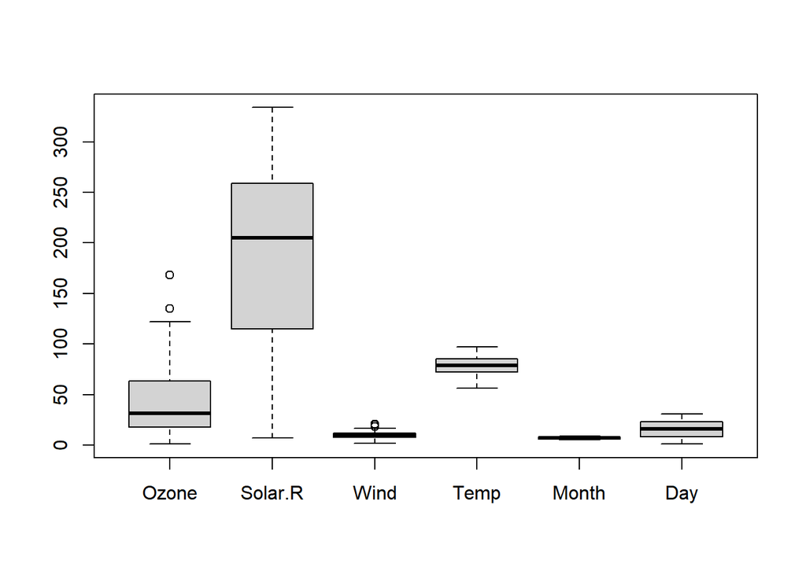

```r
boxplot(airquality)
```

### Data Transformation

```r
library(caret)
summary(cars)
```

```
##      speed           dist
##  Min.   : 4.0   Min.   :  2.00
##  1st Qu.:12.0   1st Qu.: 26.00
##  Median :15.0   Median : 36.00
##  Mean   :15.4   Mean   : 42.98
##  3rd Qu.:19.0   3rd Qu.: 56.00
##  Max.   :25.0   Max.   :120.00
```

```r
data_norm_model <- preProcess(cars,method="range") # Apply range normalization
cars_range_norm <- predict(data_norm_model,cars)
summary(cars_range_norm)
```

```
##      speed             dist
##  Min.   :0.0000   Min.   :0.0000
##  1st Qu.:0.3810   1st Qu.:0.2034
##  Median :0.5238   Median :0.2881
##  Mean   :0.5429   Mean   :0.3473
##  3rd Qu.:0.7143   3rd Qu.:0.4576
##  Max.   :1.0000   Max.   :1.0000
```

```r
data_norm_z <- preProcess(cars,method=c("center","scale")) # Z normalization
cars_z_norm <- predict(data_norm_z,cars)
summary(cars_z_norm)
```

```
##      speed               dist
##  Min.   :-2.15597   Min.   :-1.5903
##  1st Qu.:-0.64301   1st Qu.:-0.6589
##  Median :-0.07565   Median :-0.2709
##  Mean   : 0.00000   Mean   : 0.0000
##  3rd Qu.: 0.68083   3rd Qu.: 0.5053
##  Max.   : 1.81555   Max.   : 2.9888
```

```r
library(ISLR)
head(Wage)
```

```
##        year age           maritl     race       education             region
## 231655 2006  18 1. Never Married 1. White    1. < HS Grad 2. Middle Atlantic
## 86582  2004  24 1. Never Married 1. White 4. College Grad 2. Middle Atlantic
## 161300 2003  45       2. Married 1. White 3. Some College 2. Middle Atlantic
## 155159 2003  43       2. Married 3. Asian 4. College Grad 2. Middle Atlantic
## 11443  2005  50      4. Divorced 1. White      2. HS Grad 2. Middle Atlantic
## 376662 2008  54       2. Married 1. White 4. College Grad 2. Middle Atlantic
##              jobclass         health health_ins  logwage      wage
## 231655  1. Industrial      1. <=Good      2. No 4.318063  75.04315
## 86582  2. Information 2. >=Very Good      2. No 4.255273  70.47602
## 161300  1. Industrial      1. <=Good     1. Yes 4.875061 130.98218
## 155159 2. Information 2. >=Very Good     1. Yes 5.041393 154.68529
## 11443  2. Information      1. <=Good     1. Yes 4.318063  75.04315
## 376662 2. Information 2. >=Very Good     1. Yes 4.845098 127.11574
```

```r
summary(Wage)
```

```
##       year           age                     maritl           race
##  Min.   :2003   Min.   :18.00   1. Never Married: 648   1. White:2480
##  1st Qu.:2004   1st Qu.:33.75   2. Married      :2074   2. Black: 293
##  Median :2006   Median :42.00   3. Widowed      :  19   3. Asian: 190
##  Mean   :2006   Mean   :42.41   4. Divorced     : 204   4. Other:  37
##  3rd Qu.:2008   3rd Qu.:51.00   5. Separated    :  55
##  Max.   :2009   Max.   :80.00
##
##               education                     region               jobclass
##  1. < HS Grad      :268   2. Middle Atlantic   :3000   1. Industrial :1544
##  2. HS Grad        :971   1. New England       :   0   2. Information:1456
##  3. Some College   :650   3. East North Central:   0
##  4. College Grad   :685   4. West North Central:   0
##  5. Advanced Degree:426   5. South Atlantic    :   0
##                           6. East South Central:   0
##                           (Other)              :   0
##             health      health_ins      logwage           wage
##  1. <=Good     : 858   1. Yes:2083   Min.   :3.000   Min.   : 20.09
##  2. >=Very Good:2142   2. No : 917   1st Qu.:4.447   1st Qu.: 85.38
##                                      Median :4.653   Median :104.92
##                                      Mean   :4.654   Mean   :111.70
##                                      3rd Qu.:4.857   3rd Qu.:128.68
##                                      Max.   :5.763   Max.   :318.34
##
```

```r
dummy_model <- dummyVars(~race,data=Wage)
head(predict(dummy_model,Wage))
```

```
##        race.1. White race.2. Black race.3. Asian race.4. Other
## 231655             1             0             0             0
## 86582              1             0             0             0
## 161300             1             0             0             0
## 155159             0             0             1             0
## 11443              1             0             0             0
## 376662             1             0             0             0
```

### Partitioning Data: Training, Validation, and Test

```r
summary(Default)
```

```
##  default    student       balance           income
##  No :9667   No :7056   Min.   :   0.0   Min.   :  772
##  Yes: 333   Yes:2944   1st Qu.: 481.7   1st Qu.:21340
##                        Median : 823.6   Median :34553
##                        Mean   : 835.4   Mean   :33517
##                        3rd Qu.:1166.3   3rd Qu.:43808
##                        Max.   :2654.3   Max.   :73554
```

```r
index_train <- createDataPartition(Default$default,p=0.6,list = F)
train_data <- Default[index_train,]
rest_data <- Default[-index_train,]
nrow(train_data)
```

```
## [1] 6001
```

## Putting it Together

1. Import Data: `read.csv`
2. Clean up Data: Missing values, imputing data, converting variables
3. Create new variables: `mutate()`
4. Split data: Training, Validation, Test: `createDataPartition()`
5. Normalization: Range and Z normalization: `preProcess(), predict()`

### Help

- [Cheat Sheet](https://www.rstudio.com/wp-content/uploads/2015/02/data-wrangling-cheatsheet.pdf)